# Social Forecasting Tutorial 4

Martyn Egan

06/04/2023

# Time Series Regression Models

In last week’s class we looked at data-driven approaches to forecasting time series. This week we will look at model-driven approaches, in particular *regression-based* models and *autoregressive* models (e.g. ARIMA).

## Regression models

The basic principles of time series regression will be familiar to you from cross-sectional regression methods. In time series regression, the predictor variable (x) is the time index, and the outcome (y) is the time series measurement or some function of it. The model will find the values of beta 0 (the time series’ level), beta 1 (trend), and the noise (e). An example is given below using the familiar Amtrak dataset.

```r
amtrak <- read.csv("data/Amtrak.csv") #read in data
amtrak.ts <- ts(amtrak$Ridership, start = c(1991, 1), end = c(2004, 3), frequency = 12)

train.ts <- window(amtrak.ts, end = c(1991, length(amtrak.ts) - 36)) #create a training set

train.lm <- tslm(train.ts ~ trend) #the `trend` argument includes the time index as a linear predictor

summary(train.lm)
```

```
##
## Call:
## tslm(formula = train.ts ~ trend)
##
## Residuals:
##     Min      1Q  Median      3Q     Max
## -411.29 -114.02   16.06  129.28  306.35
##
## Coefficients:
##              Estimate Std. Error t value Pr(>|t|)
## (Intercept) 1750.3595    29.0729  60.206   <2e-16 ***
## trend          0.3514     0.4069   0.864     0.39
## ---
## Signif. codes:  0 '***' 0.001 '**' 0.01 '*' 0.05 '.' 0.1 ' ' 1
##
## Residual standard error: 160.2 on 121 degrees of freedom
## Multiple R-squared:  0.006125,   Adjusted R-squared:  -0.002089
## F-statistic: 0.7456 on 1 and 121 DF,  p-value: 0.3896
```

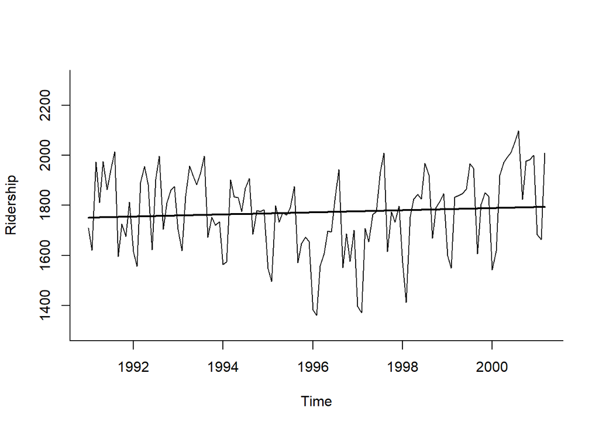

```r
plot(train.ts, xlab = "Time", ylab = "Ridership", ylim = c(1300, 2300), bty = "l")
lines(train.lm$fitted, lwd = 2)
```

We can use the `forecast()` function in the the `forecast` package to predict the values from the validation set using the training model.

```r
train.lm.pred <- forecast(train.lm, h = 36, level = 0)

accuracy(train.lm.pred, amtrak.ts)
```

```
##                        ME     RMSE      MAE       MPE      MAPE     MASE
## Training set 3.720601e-15 158.9269 129.6778 -0.853984  7.535999 1.572005
## Test set     1.931316e+02 239.4863 209.4371  9.209919 10.147732 2.538879
##                   ACF1 Theil's U
## Training set 0.4372087        NA
## Test set     0.2734545  1.358369
```

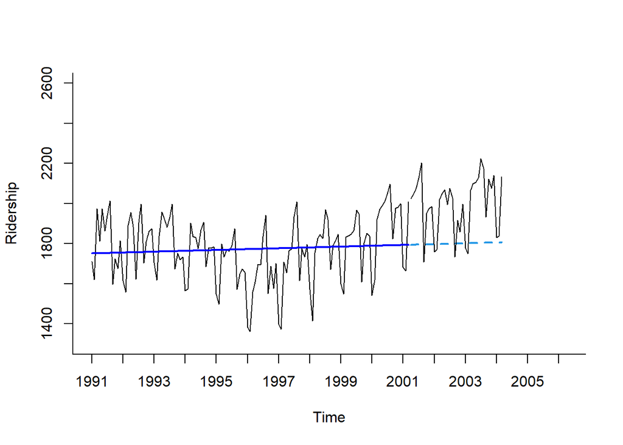

```r
plot(train.lm.pred, ylim = c(1300, 2600), ylab = "Ridership", xlab = "Time", bty = "l",
     xaxt = "n", xlim = c(1991, 2006.25), main = "", flty = 2)
axis(1, at = seq(1991, 2006, 1), labels = format(seq(1991, 2006, 1)))
lines(train.lm.pred$fitted, lwd = 2, col = "blue")
lines(window(amtrak.ts, start = c(1991, length(amtrak.ts) - 35), end = c(1991, length(amtrak.ts))))
```

To model a non-linear trend, we simply adjust the formula, as we would using the `lm()` function.

```r
train.lm.e <- tslm(train.ts ~ trend, lambda = 0) #to model an exponential trend, we set the lambda argument to zero (a value of 1 is linear)

train.lm.poly <- tslm(train.ts ~ trend + I(trend^2)) #to model a quadratic trend, we add the squared term.
```

## Trend and Seasonality

In order to model the effects of seasonality on our time series, we can add an additional variable with the relevant season for each observation (i.e. month, quarter, day, etc.). This will provide a coefficient for each frequency, similar to adding a categorical variable to a regression of cross-sectional data. The `tslm()` function automates the process.

```r
train.lm.se <- tslm(train.ts ~ season)
summary(train.lm.se)
```

```
##
## Call:
## tslm(formula = train.ts ~ season)
##
## Residuals:
##      Min       1Q   Median       3Q      Max
## -276.165  -52.934    5.868   54.544  215.081
##
## Coefficients:
##             Estimate Std. Error t value Pr(>|t|)
## (Intercept)  1573.97      30.58  51.475  < 2e-16 ***
## season2       -42.93      43.24  -0.993   0.3230
## season3       260.77      43.24   6.030 2.19e-08 ***
## season4       245.09      44.31   5.531 2.14e-07 ***
## season5       278.22      44.31   6.279 6.81e-09 ***
## season6       233.46      44.31   5.269 6.82e-07 ***
## season7       345.33      44.31   7.793 3.79e-12 ***
## season8       396.66      44.31   8.952 9.19e-15 ***
## season9        75.76      44.31   1.710   0.0901 .
## season10      200.61      44.31   4.527 1.51e-05 ***
## season11      192.36      44.31   4.341 3.14e-05 ***
## season12      230.42      44.31   5.200 9.18e-07 ***
## ---
## Signif. codes:  0 '***' 0.001 '**' 0.01 '*' 0.05 '.' 0.1 ' ' 1
##
## Residual standard error: 101.4 on 111 degrees of freedom
## Multiple R-squared:  0.6348, Adjusted R-squared:  0.5986
## F-statistic: 17.54 on 11 and 111 DF,  p-value: < 2.2e-16
```

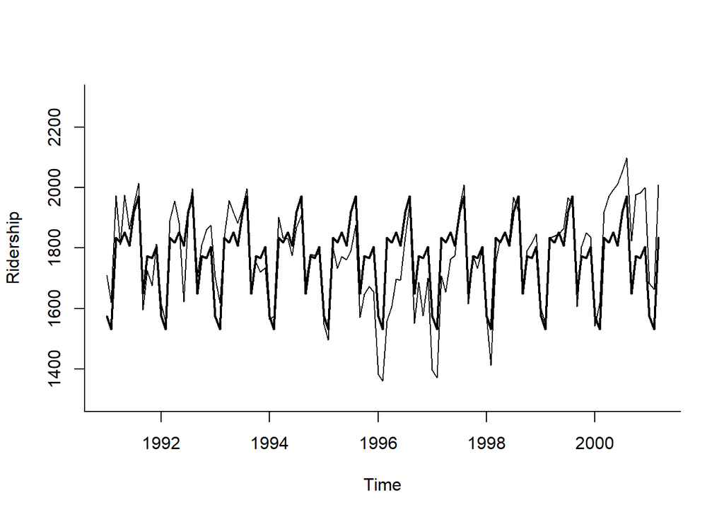

```r
plot(train.ts, xlab = "Time", ylab = "Ridership", ylim = c(1300, 2300), bty = "l")
lines(train.lm.se$fitted, lwd = 2)
```

As we see from the plot above, the effect of modeling **only** seasonality is to create a repeating seasonal pattern throughout the data, with no trend. It is important to remember that `R` will model f-1 seasons to avoid multicollinearity; the intercept is thus the mean plus the conditional mean of the reference month (in this case January). We interpret the output therefore as March (season3) will have on average 260,000 more passengers than January, or that January will have 260,000 fewer passengers than March.

Generally speaking, for time series which demonstrate both trend and seasonality, you will want to model both effects simultaneously. Below we model a quadratic trend with seasonality.

```r
train.lm.poly.se <- tslm(train.ts ~ trend + I(trend^2) + season)
summary(train.lm.poly.se)
```

```
##
## Call:
## tslm(formula = train.ts ~ trend + I(trend^2) + season)
##
## Residuals:
##      Min       1Q   Median       3Q      Max
## -213.775  -39.363    9.711   42.422  152.187
##
## Coefficients:
##               Estimate Std. Error t value Pr(>|t|)
## (Intercept)  1.697e+03  2.768e+01  61.318  < 2e-16 ***
## trend       -7.156e+00  7.293e-01  -9.812  < 2e-16 ***
## I(trend^2)   6.074e-02  5.698e-03  10.660  < 2e-16 ***
## season2     -4.325e+01  3.024e+01  -1.430  0.15556
## season3      2.600e+02  3.024e+01   8.598 6.60e-14 ***
## season4      2.606e+02  3.102e+01   8.401 1.83e-13 ***
## season5      2.938e+02  3.102e+01   9.471 6.89e-16 ***
## season6      2.490e+02  3.102e+01   8.026 1.26e-12 ***
## season7      3.606e+02  3.102e+01  11.626  < 2e-16 ***
## season8      4.117e+02  3.102e+01  13.270  < 2e-16 ***
## season9      9.032e+01  3.102e+01   2.911  0.00437 **
## season10     2.146e+02  3.102e+01   6.917 3.29e-10 ***
## season11     2.057e+02  3.103e+01   6.629 1.34e-09 ***
## season12     2.429e+02  3.103e+01   7.829 3.44e-12 ***
## ---
## Signif. codes:  0 '***' 0.001 '**' 0.01 '*' 0.05 '.' 0.1 ' ' 1
##
## Residual standard error: 70.92 on 109 degrees of freedom
## Multiple R-squared:  0.8246, Adjusted R-squared:  0.8037
## F-statistic: 39.42 on 13 and 109 DF,  p-value: < 2.2e-16
```

```r
train.lm.poly.se.pred <- forecast(train.lm.poly.se, h = 36, level = 0)

accuracy(train.lm.poly.se.pred, amtrak.ts)
```

```
##                         ME      RMSE       MAE        MPE     MAPE      MASE
## Training set -1.854553e-15  66.76143  51.95091 -0.1525653 3.015509 0.6297693
## Test set     -1.261654e+02 153.25066 131.72503 -6.4314945 6.698700 1.5968226
##                   ACF1 Theil's U
## Training set 0.6040588        NA
## Test set     0.7069291 0.8960679
```

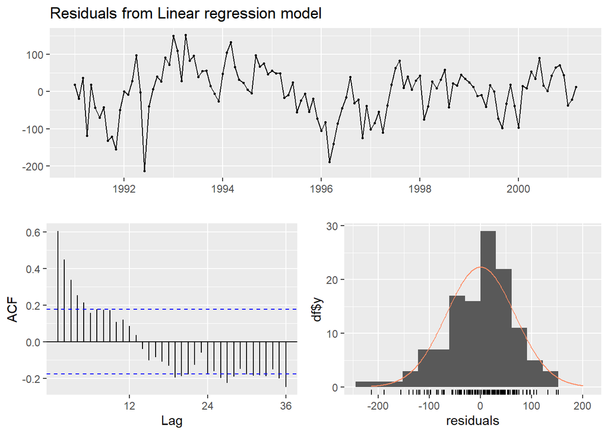

```
##
##  Ljung-Box test
##
## data:  Residuals from Linear regression model
## Q* = 151.62, df = 24, p-value < 2.2e-16
##
## Model df: 0.   Total lags used: 24
```

```r
checkresiduals(train.lm.poly.se.pred)
```

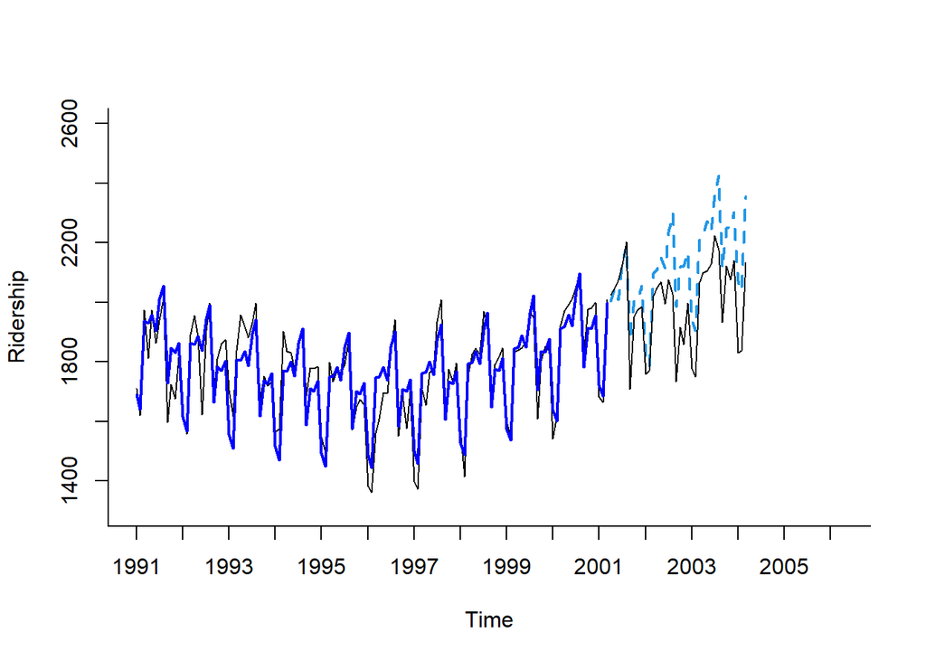

```r
plot(train.lm.poly.se.pred, ylim = c(1300, 2600), ylab = "Ridership", xlab = "Time",
     bty = "l", xaxt = "n", xlim = c(1991, 2006.25), main = "", flty = 2)
axis(1, at = seq(1991, 2006, 1), labels = format(seq(1991, 2006, 1)))
lines(train.lm.poly.se.pred$fitted, lwd = 2, col = "blue")
lines(window(amtrak.ts, start = c(1991, length(amtrak.ts) - 35), end = c(1991, length(amtrak.ts))))
```

## Smooth Seasonality

A final note on seasonality: where the transition from one season to the next is smooth, forecasters sometimes add sinusoidal functions as predictors to capture the smooth seasonality pattern, with the general formula 2 x pi x trend / number of seasons (i.e. 52.18 for weeks, 365.25 for days). The code belows illustrates how to implement this for the Amtrak dataset.

```r
train.lm.sm <- tslm(train.ts ~ trend + I(trend^2) + I(sin(2*pi*trend/12))
                    + I(cos(2*pi*trend/12)))

train.lm.sm.pred <- forecast(train.lm.sm, h = 36, level = 0)

accuracy(train.lm.sm.pred, amtrak.ts)
```

```
##                         ME     RMSE       MAE        MPE     MAPE     MASE
## Training set -1.108903e-14 118.6028  99.03092 -0.4812019 5.754723 1.200492
## Test set     -1.172127e+02 176.4230 137.84394 -6.2407879 7.236374 1.670998
##                    ACF1 Theil's U
## Training set 0.07283181        NA
## Test set     0.20204265  1.024266
```

In this case, adding smooth seasonality reduces the accuracy of the model.

## Autocorrelation and autoregressive (AR) models

Last week we looked at differencing (lagging) time series data and autocorrelation plots. Autocorrelation describes a relationship between the series and itself, and can be informative in improving forecasts. For instance, in the ACF of the quadratic seasonal model above, we can see that the first 5 lags all exhibit statistically significant autocorrelation. We can interpret this positive correlation as “stickiness” within the series, where consecutive values generally move in the same direction. A negative lag-1 autocorrelation, by contrast, would reflect swings in the data, with high and low values alternating.

There are two approaches to capturing autocorrelation: autoregressive models (AR) and AutoRegressive Integrated Moving Average (ARIMA). We will first look at applying AR as a second-layer model to a pre-existing regression model, in this case our quadratic seasonal model. Essentially, AR as a second-layer model involves fitting an AR model to the series of residuals from the first model. In practice, the `Arima()` function from the `forecast` automates the process. Here, we apply the argument `order = c(1,0,0)` to specify we want the AR model.

```r
train.res.ar <- Arima(train.lm.poly.se$residuals, order = c(1,0,0)) #train an AR on the residuals
train.res.ar.pred <- forecast(train.res.ar, h = 36) #forecast results

summary(train.res.ar)
```

```
## Series: train.lm.poly.se$residuals
## ARIMA(1,0,0) with non-zero mean
##
## Coefficients:
##          ar1     mean
##       0.5998   0.3728
## s.e.  0.0712  11.8408
##
## sigma^2 = 2876:  log likelihood = -663.54
## AIC=1333.08   AICc=1333.29   BIC=1341.52
##
## Training set error measures:
##                      ME     RMSE     MAE      MPE     MAPE      MASE
## Training set -0.1223159 53.19141 39.8277 103.3885 175.2219 0.5721356
##                     ACF1
## Training set -0.07509305
```

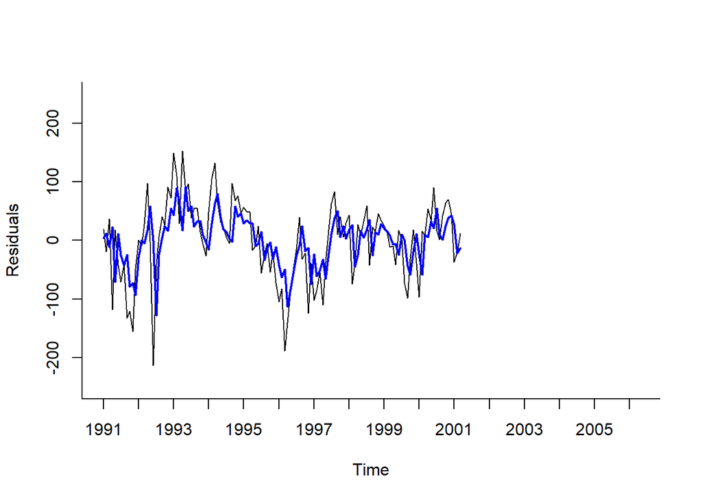

```r
#plot model against residuals
plot(train.lm.poly.se$residuals, ylim = c(-250, 250), ylab = "Residuals",
     xlab = "Time", bty = "l", xaxt = "n", xlim = c(1991, 2006.25), main = "")
axis(1, at = seq(1991, 2006, 1), labels  = format(seq(1991, 2006, 1)))
lines(train.res.ar.pred$fitted, lwd = 2, col = "blue")
```

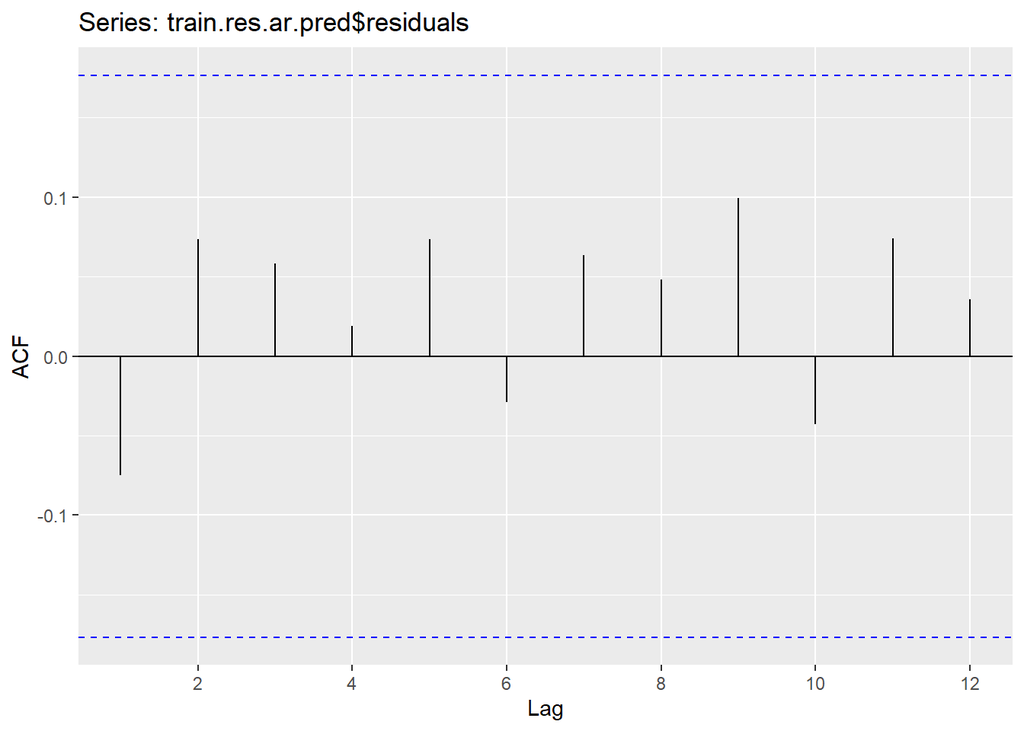

```r
#check autocorrelation of residuals-of-residuals
ggAcf(train.res.ar.pred$residuals, lag.max = 12)
```

It is clear from the ACF that no more autocorrelation remains, and the AR(1) model has captured the autocorrelation information adequately. See p149 of the textbook for interpretation of the AR(1) model.

## ARIMA

ARIMA models are more flexible than AR models, but require more expertise. They include three terms: **p** is the number of autoregressive terms in the model, **q** is the number of moving average terms, and **d** is the number of integrated terms (or number of times a series is differenced before an ARMA model is applied). Because AR and ARIMA models can only be fitted to data without trend or seasonality, the **d** parameter is used to remove trend through differencing (1 = a linear trend, at lag-1; 2 = twice differencing the trend at lag-1 for quadratic trends, etc.) A seasonal-ARIMA model incorporates a step of differencing to remove seasonality.

Because it can be difficult to specify the correct parameters for an ARIMA model, we will use the `auto.arima()` function (develop by Hyndman and Khandakar), which uses a combination of MLE and a stepwise search, to estimate the best parameters for us.

```r
auto.arima(train.ts)
```

```
## Series: train.ts
## ARIMA(1,1,1)(0,1,1)[12]
##
## Coefficients:
##          ar1      ma1     sma1
##       0.3221  -0.7446  -0.7017
## s.e.  0.1644   0.1185   0.1021
##
## sigma^2 = 4032:  log likelihood = -615.44
## AIC=1238.88   AICc=1239.26   BIC=1249.68
```

According to the `auto.arima()` function, the best parameters for an ARIMA model on the Amtrak data are an autocorrelation (p) of 1, lag-1 differencing to remove trend (d), and autocorrelation of 1 for the errors. The second brackets relate to the seasonality parameters, which `auto.arima()` estimates as 0 for p, 1 for d, and 1 for q. Let’s run an ARIMA model with these parameters.

```r
train.ARIMA <- auto.arima(train.ts)
summary(train.ARIMA)
```

```
## Series: train.ts
## ARIMA(1,1,1)(0,1,1)[12]
##
## Coefficients:
##          ar1      ma1     sma1
##       0.3221  -0.7446  -0.7017
## s.e.  0.1644   0.1185   0.1021
##
## sigma^2 = 4032:  log likelihood = -615.44
## AIC=1238.88   AICc=1239.26   BIC=1249.68
##
## Training set error measures:
##                    ME     RMSE      MAE      MPE     MAPE     MASE        ACF1
## Training set 6.754576 59.22559 45.54802 0.297054 2.593327 0.552151 -0.03298123
```

```r
train.ARIMA.pred <- forecast(train.ARIMA, h = 36)

accuracy(train.ARIMA.pred, amtrak.ts)
```

```
##                      ME     RMSE      MAE       MPE     MAPE      MASE
## Training set   6.754576 59.22559 45.54802  0.297054 2.593327 0.5521510
## Test set     -45.985990 76.50042 53.04340 -2.388290 2.739223 0.6430129
##                     ACF1 Theil's U
## Training set -0.03298123        NA
## Test set      0.57951613 0.4483051
```

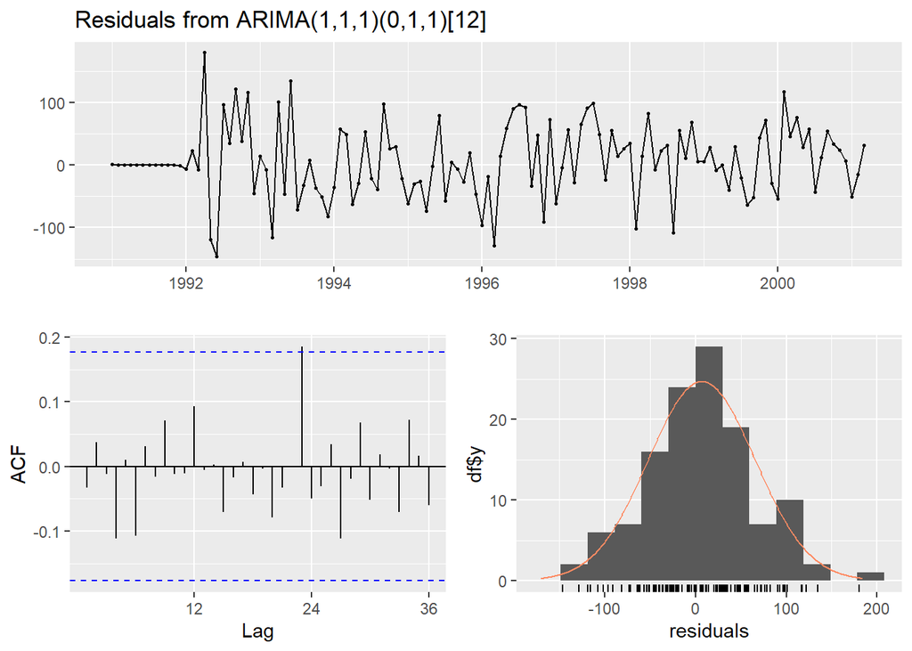

```
##
##  Ljung-Box test
##
## data:  Residuals from ARIMA(1,1,1)(0,1,1)[12]
## Q* = 13.302, df = 21, p-value = 0.8977
##
## Model df: 3.   Total lags used: 24
```

```r
checkresiduals(train.ARIMA.pred)
```

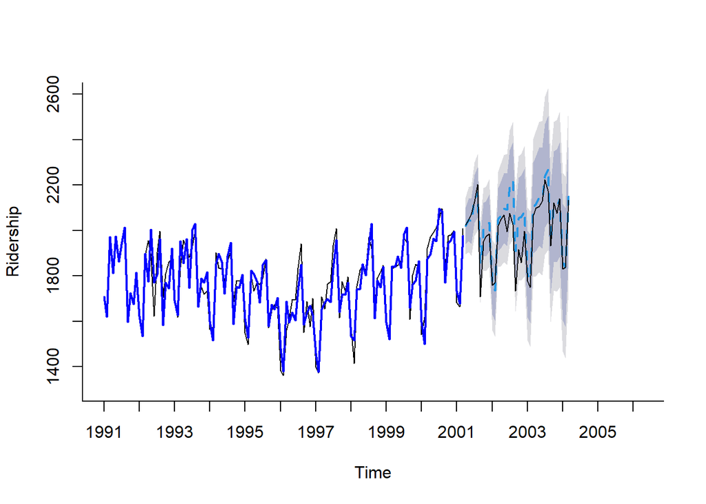

```r
plot(train.ARIMA.pred, ylim = c(1300, 2600), ylab = "Ridership", xlab = "Time",
     bty = "l", xaxt = "n", xlim = c(1991, 2006.25), main = "", flty = 2)
axis(1, at = seq(1991, 2006, 1), labels = format(seq(1991, 2006, 1)))
lines(train.ARIMA.pred$fitted, lwd = 2, col = "blue")
lines(window(amtrak.ts, start = c(1991, length(amtrak.ts) - 35), end = c(1991, length(amtrak.ts))))
```

Our RMSE from using the ARIMA model to forecast the time series is 76.5 - roughly half what we achieved through the quadratic plus seasonal regression model.

Note: the `auto.arima()` function also takes a `lamda =` argument, for applying Box-Cox transformations to data. A lambda of 2 is equivalent to y squared. We saw in our regression model that a quadratic transformation gave the best fit, so let’s try adding a lambda of 2 to the ARIMA model. (The values are automatically transformed back when forecasting.)

```r
train.ARIMA.lbda.pred <- train.ts %>%
  auto.arima(lambda = 2) %>%
  forecast(h = 36)

accuracy(train.ARIMA.lbda.pred, amtrak.ts)
```

```
##                      ME     RMSE      MAE       MPE     MAPE      MASE
## Training set   6.366569 59.42107 45.35888  0.272874 2.581114 0.5498581
## Test set     -41.922164 73.84570 51.68794 -2.231280 2.695867 0.6265815
##                     ACF1 Theil's U
## Training set -0.01792882        NA
## Test set      0.53610870 0.4331041
```

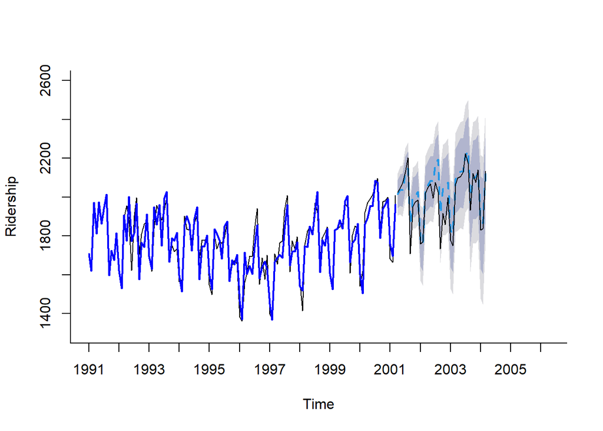

```r
plot(train.ARIMA.lbda.pred, ylim = c(1300, 2600), ylab = "Ridership", xlab = "Time",
     bty = "l", xaxt = "n", xlim = c(1991, 2006.25), main = "", flty = 2)
axis(1, at = seq(1991, 2006, 1), labels = format(seq(1991, 2006, 1)))
lines(train.ARIMA.lbda.pred$fitted, lwd = 2, col = "blue")
lines(window(amtrak.ts, start = c(1991, length(amtrak.ts) - 35), end = c(1991, length(amtrak.ts))))
```

We see a further slight improvement in RMSE with a lambda of 2. If you are unsure about the correct value of lambda, the `BoxCox.lambda()` function will estimate the optimal parameter (which in this case is very close to 2).

### Task

The `SouvenirSales` time series contains monthly sales for a souvenir shop at a beach resort town in Queensland, Australia, between 1995 and 2001. Your task is to build the best 12 month forecast model for the dataset. Make sure to:

- Create an appropriate training period.
- Examine the time plot of the data.
- Check for autocorrelations.
- Check for any required transformations.

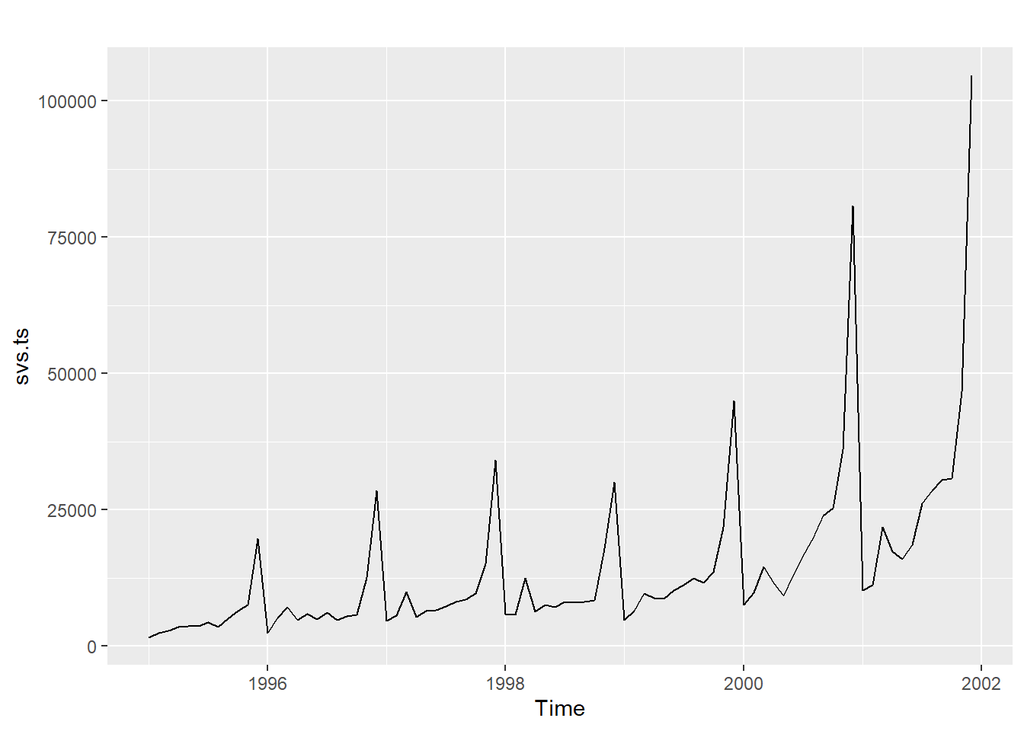

```r
svs <- read.csv("data/SouvenirSales.csv") #read in file
svs.ts <- ts(svs[,2], start = c(1995, 1), end = c(2001, 12), frequency = 12) #convert to ts

svs.train <- window(svs.ts, start = c(1995,1), end = c(1995, length(svs.ts)-12))

autoplot(svs.ts) #we see trend and multiplicative seasonality
```

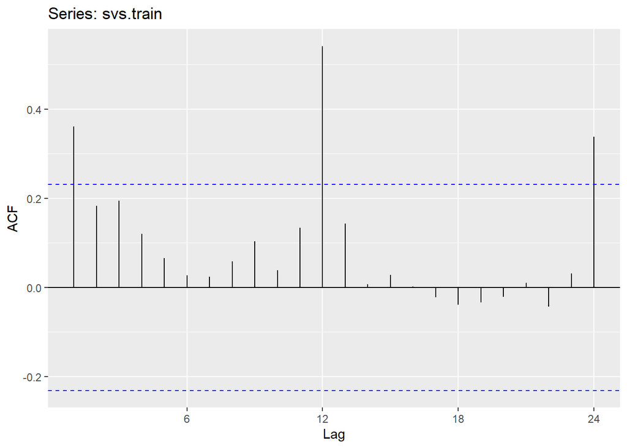

```r
ggAcf(svs.train) #strong autocorrelation in lag-1, strong seasonal trend at 12 and 24 months
```

```r
BoxCox.lambda(svs.train) #it seems the optimal transformation is close to log (0.015)
```

```
## [1] 0.01548915
```

```r
svs.train.ARIMA.pred <- svs.train %>%
  auto.arima(lambda = 0.015) %>% #run an ARIMA
  forecast(h = 12)

accuracy(svs.train.ARIMA.pred, svs.ts) #check accuracy
```

```
##                      ME     RMSE      MAE        MPE     MAPE      MASE
## Training set   52.87821 2074.671 1362.625 -1.1391698 11.66170 0.3638712
## Test set     1888.08296 4518.654 3300.794  0.5950175 11.90068 0.8814339
##                    ACF1 Theil's U
## Training set 0.07017793        NA
## Test set     0.39206323 0.3611301
```

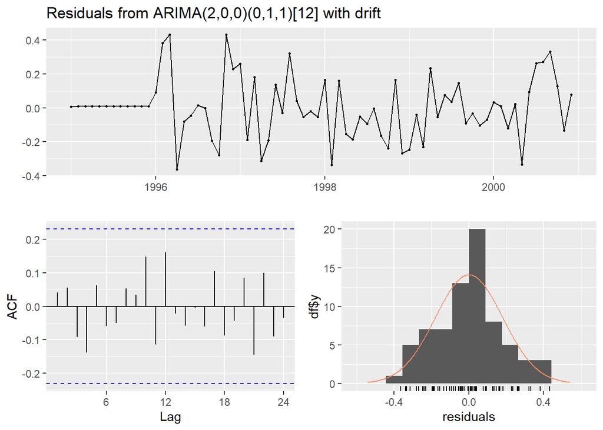

```
##
##  Ljung-Box test
##
## data:  Residuals from ARIMA(2,0,0)(0,1,1)[12] with drift
## Q* = 9.3158, df = 11, p-value = 0.5928
##
## Model df: 3.   Total lags used: 14
```

```r
checkresiduals(svs.train.ARIMA.pred) #check residuals
```

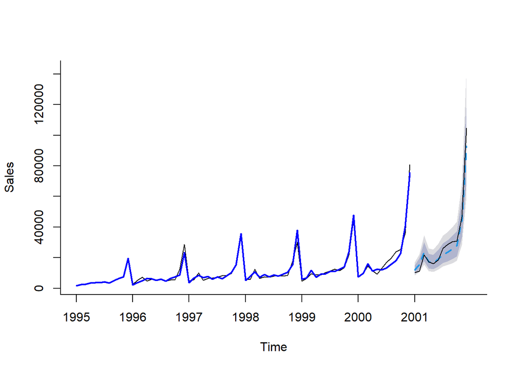

```r
plot(svs.train.ARIMA.pred, ylab = "Sales", xlab = "Time",
     bty = "l", xaxt = "n", xlim = c(1995, 2002), main = "", flty = 2)
axis(1, at = seq(1995, 2001, 1), labels = format(seq(1995, 2001, 1)))
lines(svs.train.ARIMA.pred$fitted, lwd = 2, col = "blue")
lines(window(svs.ts, start = c(1995, length(svs.ts) - 11), end = c(1995, length(svs.ts))))
```